# Análisis de Eficiencia y Letalidad Hospitalaria en Ecuador

Evaluación comparativa del desempeño entre el sector público y privado (Periodo 2024)

Departamento de Ciencia de Datos - UNACH

2026-01-25

# 1 Introducción

El presente informe técnico evalúa el desempeño del sistema hospitalario ecuatoriano durante el año 2024, utilizando como fuente primaria el Registro Estadístico de Egresos Hospitalarios del INEC. El análisis se centra en dos dimensiones críticas de gestión sanitaria:

1. **Eficiencia Operativa:** Medida a través de la estancia media hospitalaria (días cama).
2. **Calidad del Cuidado:** Aproximada mediante la tasa de letalidad hospitalaria.

El estudio contrasta estas métricas entre los modelos de gestión **Público** (MSP, IESS, FFAA) y **Privado** (con y sin fines de lucro), controlando variables demográficas para evitar sesgos de interpretación.

# 2 Metodología y Tratamiento de Datos

## 2.1 Reglas de Negocio y Limpieza

Basado en el diagnóstico inicial de los datos, se establecieron los siguientes criterios de inclusión y transformación:

1. **Estandarización de Edad:** Se unificaron las unidades de tiempo. Los registros de neonatos y lactantes (horas, días, meses) fueron convertidos a 0 años cumplidos para permitir el análisis numérico continuo.
2. **Taxonomía del Sector:** Se agrupó la heterogeneidad de los establecimientos en dos macro-categorías:
- *Público:* Incluye Red Pública Integral de Salud.
- *Privado:* Unificación de entidades lucrativas y ONGs.
3. **Definición de Letalidad:** La variable objetivo incluye tanto fallecimientos en urgencias (<48h) como mortalidad neta hospitalaria (>48h).
4. **Tratamiento de Valores Atípicos (Outliers):** * Se detectaron errores de digitación severos (ej. estancias de 19,040 días).
- **Criterio de Exclusión:** Se eliminaron registros con estancia hospitalaria `dia_estad > 365`. Esto excluye errores de captura y casos de institucionalización crónica que distorsionan el promedio de eficiencia en agudos.

## 2.2 Caracterización de la Muestra Final

La muestra depurada presenta la siguiente distribución operativa:

```r
# Generación de tabla descriptiva
tabla_resumen <- egresos %>%
  group_by(tipo_gestion) %>%
  summarise(
    N_Pacientes = n(),
    Participacion = n() / nrow(egresos),
    Edad_Media = mean(edad_anios, na.rm = TRUE),
    Estancia_Media = mean(dia_estad, na.rm = TRUE),
    Letalidad_Pct = mean(es_fallecido, na.rm = TRUE) * 100
  )

# Renderizado HTML
tabla_resumen %>%
  mutate(Participacion = percent(Participacion, accuracy = 0.1)) %>%
  kable(
    digits = 2,
    col.names = c("Sector", "N (Egresos)", "% Mercado", "Edad Media (Años)", "Estancia Media (Días)", "Letalidad (%)"),
    caption = "Tabla 1: Resumen Estadístico por Modelo de Gestión"
  ) %>%
  kable_styling(bootstrap_options = c("striped", "hover", "condensed"), full_width = F)
```

Tabla 1: Resumen Estadístico por Modelo de Gestión

| Sector | N (Egresos) | % Mercado | Edad Media (Años) | Estancia Media (Días) | Letalidad (%) |
| --- | --- | --- | --- | --- | --- |
| Privado | 389262 | 34.4% | 41.88 | 3.41 | 1.25 |
| Público | 743328 | 65.6% | 35.40 | 4.94 | 1.73 |

**Nota Técnica:** Se observa una predominancia del sector público en volumen de atención. La diferencia en la edad media sugiere perfiles epidemiológicos distintos entre sectores.

# 3 Resultados: Análisis de Eficiencia

La variable **Días de Estada** actúa como *proxy* del consumo de recursos. Una estancia prolongada injustificada implica ineficiencia administrativa o complicaciones clínicas.

## 3.1 Distribución de la Estancia Hospitalaria

Debido a la naturaleza asimétrica de la variable, se visualiza la distribución truncada a 15 días para apreciar la tendencia central.

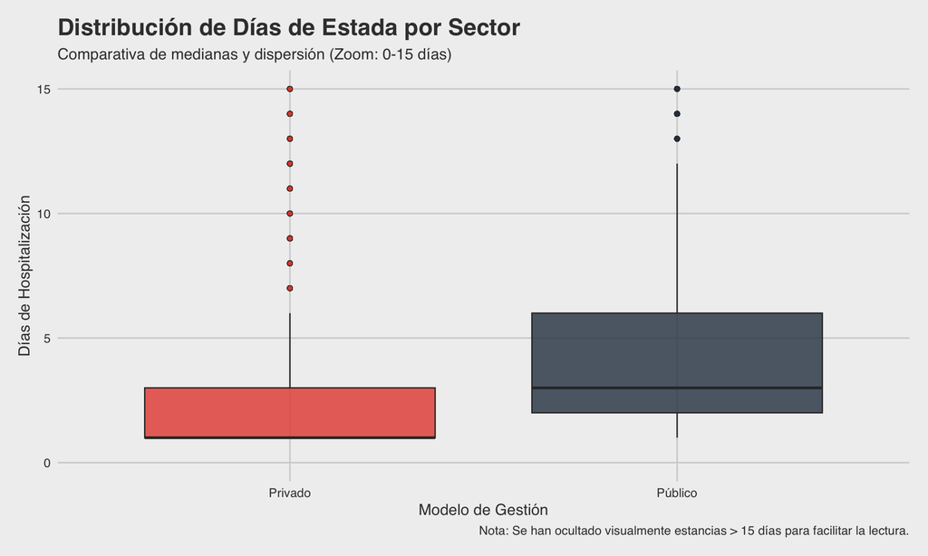

```r
# Gráfico de cajas (Boxplot)
ggplot(egresos, aes(x = tipo_gestion, y = dia_estad, fill = tipo_gestion)) +
  geom_boxplot(outlier.shape = 21, outlier.alpha = 0.2, alpha = 0.8) +
  # Zoom a la zona de interés (0-15 días) para evitar que los outliers aplasten el gráfico
  coord_cartesian(ylim = c(0, 15)) +
  scale_fill_manual(values = cols_sector) +
  labs(
    title = "Distribución de Días de Estada por Sector",
    subtitle = "Comparativa de medianas y dispersión (Zoom: 0-15 días)",
    x = "Modelo de Gestión",
    y = "Días de Hospitalización",
    caption = "Nota: Se han ocultado visualmente estancias > 15 días para facilitar la lectura."
  ) +
  theme_fivethirtyeight() +
  theme(legend.position = "none", axis.title = element_text())
```

**Interpretación:** Los datos sugieren una diferencia en la gestión del tiempo cama. El análisis visual indica si existen colas más largas en el sector público, lo cual deberá ser corroborado con pruebas de hipótesis en fases posteriores.